# Análisis de los libros mas vendidos hasta 2018 y sus características

Yonelvis Gonzalez

2025-09-14

```r
#cargamos el archivo que contiene la data
datos_libros <- read.csv("C:/Users/JOSE ROJAS/OneDrive/Desktop/Yone/archive/best-selling-books.csv")
```

Esta breve investigación esta basada en un dataset de los libros que mas copias han vendido hasta el año 2018,en el mismo podemos encontrar información como sus autores, dividiendo los libros por su idioma original, genero y un estimado en millones en ventas.

```r
#la libreria "DT" nos permite monstrar el data frame completo
datatable(datos_libros)
```

|  | Book | Author.s. | Original.language | First.published | Approximate.sales.in.millions | Genre |
| --- | --- | --- | --- | --- | --- | --- |
| 1 | A Tale of Two Cities | Charles Dickens | English | 1859 | 200 | Historical fiction |
| 2 | The Little Prince (Le Petit Prince) | Antoine de Saint-Exupéry | French | 1943 | 200 | Novella |
| 3 | Harry Potter and the Philosopher's Stone | J. K. Rowling | English | 1997 | 120 | Fantasy |
| 4 | And Then There Were None | Agatha Christie | English | 1939 | 100 | Mystery |
| 5 | Dream of the Red Chamber (紅樓夢) | Cao Xueqin | Chinese | 1791 | 100 | Family saga |
| 6 | The Hobbit | J. R. R. Tolkien | English | 1937 | 100 | Fantasy |
| 7 | The Lion, the Witch and the Wardrobe | C. S. Lewis | English | 1950 | 85 | Fantasy, Children's fiction |
| 8 | She: A History of Adventure | H. Rider Haggard | English | 1887 | 83 | Adventure |
| 9 | Vardi Wala Gunda (वर्दी वाला गुंडा) | Ved Prakash Sharma | Hindi | 1992 | 80 | Detective |
| 10 | The Da Vinci Code | Dan Brown | English | 2003 | 80 | Mystery thriller |

[output cut: 164 more lines]

## 1. Limpiamos el data frame

A la hora de trabajar con nuestro data frame es importante asegurarse de que tengamos la información lo mas precisa posible para así poder entregar unos resultamos confiables.

Para esto se eliminaran los datos errados o faltantes donominados **“NA”** y luego usaremos la función **sumary** que nos permitira visualizar un resumen estadística de nuestras varibles a trabajar.

```r
datos_libros[datos_libros== "-99"] <- NA
#Remplazamos los datos errados sustituyendolos con "NA"
datos_libros[datos_libros == "-"] <- NA
datos_libros[datos_libros== " "] <- NA
datos_libros[datos_libros== ""] <- NA
#Nos aseguramos de no encontrar datos duplicados utilizando "distinct" dejando los datos únicos

datos_libros_sin_duplicados <- datos_libros %>% distinct()
#comprobamos por ultima vez que la data este limpia mediante el resumen estadístico antes mencionado
summary(datos_libros_sin_duplicados)
```

```
##      Book            Author.s.         Original.language  First.published
##  Length:174         Length:174         Length:174         Min.   :1304
##  Class :character   Class :character   Class :character   1st Qu.:1947
##  Mode  :character   Mode  :character   Mode  :character   Median :1974
##                                                           Mean   :1963
##                                                           3rd Qu.:1995
##                                                           Max.   :2018
##  Approximate.sales.in.millions    Genre
##  Min.   : 10.0                 Length:174
##  1st Qu.: 14.0                 Class :character
##  Median : 20.0                 Mode  :character
##  Mean   : 30.1
##  3rd Qu.: 36.3
##  Max.   :200.0
```

## 2. Relacionamos la información que nos otorgan las variables

Este trabajo esta enfocado meramente en analizar aquellas características de aquellos de los libros mas vendidos.

### ¿Cómo se clasifican de acuerdo a su genero?

Al trabajar con libros es importante identificar el genero al que pertenecen,

```r
books_genre <- datos_libros_sin_duplicados %>% filter(!is.na(Genre)) %>% count(Genre, sort = TRUE)
datatable(books_genre, caption = "Distribución del género entre los libros")
```

|  | Genre | n |
| --- | --- | --- |
| 1 | Fantasy | 10 |
| 2 | Novel | 8 |
| 3 | Self-help | 7 |
| 4 | Children's Literature | 4 |
| 5 | Historical fiction | 4 |
| 6 | Fiction | 3 |
| 7 | Children's Literature, picture book | 2 |
| 8 | Children's fiction | 2 |
| 9 | Children's literature | 2 |
| 10 | Children's novel | 2 |

[output cut: 70 more lines]

En base a este listado observamos que el **genero de fantasia** es el que esta mas presente entre los libros mas vendidos, seguido de **Novelas** y libros de **autoayuda** además de una gran cantidad de obras con generos que explican con mayor detalle la obra a la que pertenecen.

### ¿Cuál es el genero que mas vende?

```r
sales_genre <- datos_libros_sin_duplicados %>% filter(!is.na(Genre) & !is.na(Approximate.sales.in.millions)) %>% group_by(Genre) %>% summarise(total_sales = sum(Approximate.sales.in.millions)) %>% arrange(desc(total_sales))
datatable(sales_genre)
```

|  | Genre | total_sales |
| --- | --- | --- |
| 1 | Fantasy | 737 |
| 2 | Historical fiction | 295 |
| 3 | Novel | 259.5 |
| 4 | Self-help | 210 |
| 5 | Novella | 200 |
| 6 | Fantasy, Children's fiction | 120 |
| 7 | Children's fiction | 100 |
| 8 | Family saga | 100 |
| 9 | Mystery | 100 |
| 10 | Children's Literature | 94 |

[output cut: 70 more lines]

En este caso podemos observar con mayor facilidad que el genero ha generado mejores resultados en base a sus ventas ha sido la fantasia pues la misma cuenta con 737 millones de libros vendidos superando por mucho el resto de generos.

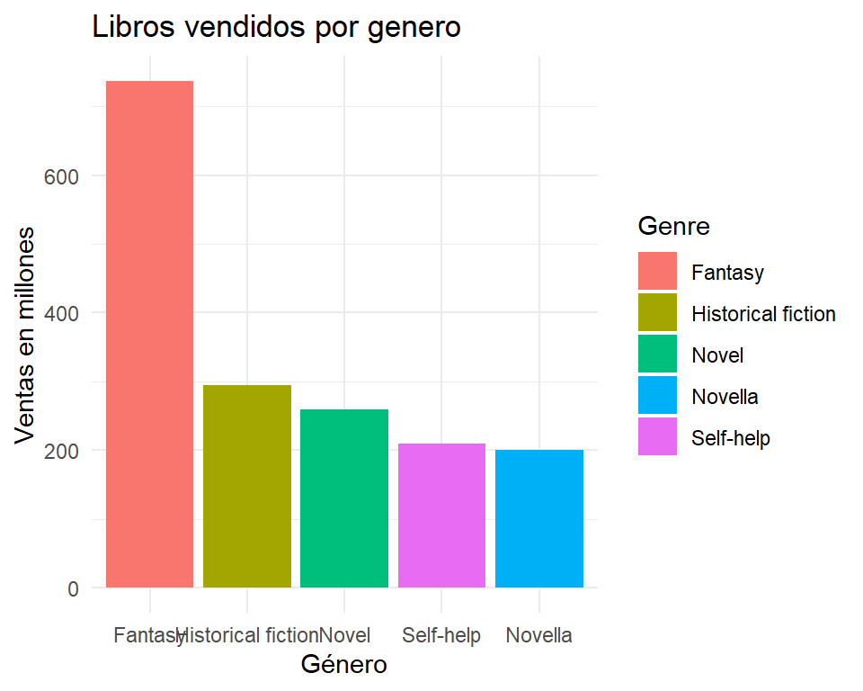

```r
sales_genre_top5 <- datos_libros_sin_duplicados %>%
  filter(!is.na(Genre) & !is.na(Approximate.sales.in.millions)) %>%
  group_by(Genre) %>%
  summarise(top_Sales = sum(Approximate.sales.in.millions)) %>%
  arrange(desc(top_Sales)) %>%
  top_n(5, top_Sales)
# Agregamos este paso para quedarnos solo con los 5 principales para visualizarlos mejor en la grafica
ggplot(sales_genre_top5, aes(x = reorder(Genre, -top_Sales), y = top_Sales, fill = Genre)) + geom_col() + labs(title = "Libros vendidos por genero", x = "Género", y = "Ventas en millones") + theme_minimal()
```

### ¿Cual es el idioma original mas repetitivo en mercado?

```r
books_idioma <- datos_libros_sin_duplicados %>% filter(!is.na(Original.language)) %>% count(Original.language, sort = TRUE)
datatable(books_idioma, caption = "Distribución de los libros según su idioma original")
```

|  | Original.language | n |
| --- | --- | --- |
| 1 | English | 131 |
| 2 | Russian | 6 |
| 3 | French | 5 |
| 4 | German | 5 |
| 5 | Japanese | 5 |
| 6 | Chinese | 4 |
| 7 | Italian | 4 |
| 8 | Spanish | 3 |
| 9 | Hindi | 2 |
| 10 | Norwegian | 2 |

[output cut: 6 more lines]

De entre los 16 idiomas presentes y los 174 libros distintos, Se puede analizar que 131 de esos libros cuentan con el ingles como idioma original, resultanto en que alrededor del 75% de los libros pertenecen a este idioma como su idioma original.

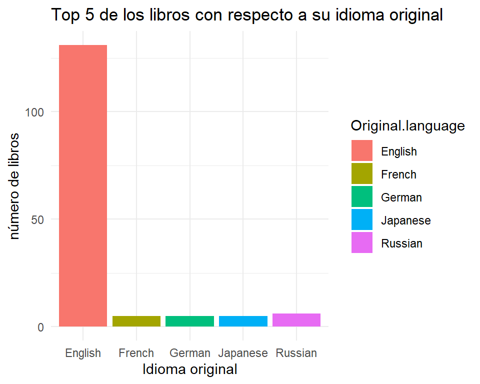

```r
books_idioma_top5 <- datos_libros_sin_duplicados %>% filter(!is.na(Original.language)) %>% count(Original.language, sort = TRUE) %>% top_n(5, n)

ggplot(books_idioma_top5, aes(x= Original.language, y= n, fill = Original.language)) + geom_col() + labs(title = "Top 5 de los libros con respecto a su idioma original", x= "Idioma original", y= "número de libros") + theme_minimal()
```